# Análise de Rotatividade (HR Analytics)

Identificação de Fatores Críticos para a Retenção de Talento

Joana Inácio | Data Analyst

12-01-2026

# Introdução e Contexto

## O Problema de Negócio

A rotatividade dos funcionários (também conhecida por *Employee Attrition*) é um dos maiores desafios das organizações, e um dos que traz mais custos. Estudos indicam que o custo de substituir um funcionário pode variar entre 50% a 200% do seu salário anual, sendo considerados os custos de recrutamento, de formação e de perda de produtividade.

Para além do impacto financeiro, uma taxa de *turnover* elevada afeta a moral das equipas, a cultura da empresa e a continuidade dos projetos. Por isso, a capacidade de prever **quem** está em risco de sair e, mais importante, **porquê**, é uma vantagem competitiva crucial para o Departamento de Recursos Humanos (RH).

## Sobre o *Dataset*

Neste projeto, foi utilizado o *dataset* “**IBM HR Analytics Employee Attrition & Performance**”, disponibilizado publicamente no Kaggle. Este conjunto de dados foi criado por cientistas de dados da IBM e, embora seja fictício, reflete desafios reais do mundo corporativo.

O *dataset* contém **1470 observações** (funcionários) e **35 variáveis** (características)

## Dicionário de Variáveis

A nossa variável-alvo (*Target*) é a *Attrition*, que indica se o funcionário saiu (“Yes”) ou permaneceu (“No”) na empresa.

As restantes variáveis podem ser agrupadas em três categorias principais que iremos explorar:

1. **Demográficas**: `Age`, `Gender`, `MaritialStatus`, `DistanceFromHome`;
2. **Dados do Trabalho**: `Department`, `JobRole`, `JobLevel`, `OverTime`, `BusinessTravel`;
3. **Compensação e Satisfação**: `MonthlyIncome`, `PercentSalaryHike`, `StockOptionLevel`, `JobSatisfaction`, `EnvironmentSatisfaction`.

## Objetivos do Projeto

O objetivo central deste projeto é desenvolver uma solução de **People Analytics** capaz de antecipar a rotatividade de talentos e fornecer à gestão estratégias baseadas em dados. Para tal, a análise foca-se em três pilares verticais:

- **Diagnóstico de Causa Raiz**: Quantificar o impacto real de fatores de risco, verificando a hipótese de que a sobrecarga de trabalho (`OverTime`) e a logística (`DistanceFromHome`) são catalisadores de *burnout*.
- **Hierarquia de Retenção**: Determinar, através de algoritmos de Machine Learning, o que pesa mais na decisão de saída: incentivos financeiros (`MonthlyIncome`) ou fatores intangíveis como a Satisfação no Trabalho.
- **Modelação Preditiva**: Treinar algoritmos de classificação (Regressão Logística e Random Forest) para identificar colaboradores em risco com elevada precisão, permitindo uma atuação preventiva do RH.

# Importação dos Dados e Inspeção Inicial

```r
# Importação dos Dados
# Lemos o ficheiro original
ibm_hr <- read.csv("data/WA_Fn-UseC_-HR-Employee-Attrition.csv", sep = ";")


library(janitor)
library(dplyr)

# Limpeza e Padronização
# Aqui criamos o objeto 'ibm_clean'

ibm_clean <- ibm_hr %>%
  clean_names() %>%
  # Removemos colunas que não variam
  select(-any_of(c("employee_count", "over18", "standard_hours", "employee_number")))

# Visualização (kable)
library(kableExtra)
ibm_clean %>%
  select(age, attrition, monthly_income, job_role, over_time, total_working_years) %>%
  head(10) %>%
  kable(caption = "Tabela 1: Amostra das Variáveis Críticas para Análise de Rotatividade") %>%
  kable_styling(bootstrap_options = c("striped", "hover", "condensed"),
                full_width = T,
                position = "center") %>%
  row_spec(0, bold = T, color = "white", background = "#2c3e50")
```

Tabela 1: Amostra das Variáveis Críticas para Análise de Rotatividade

| age | attrition | monthly_income | job_role | over_time | total_working_years |
| --- | --- | --- | --- | --- | --- |
| 41 | Yes | 5993 | Sales Executive | Yes | 8 |
| 49 | No | 5130 | Research Scientist | No | 10 |
| 37 | Yes | 2090 | Laboratory Technician | Yes | 7 |
| 33 | No | 2909 | Research Scientist | Yes | 8 |
| 27 | No | 3468 | Laboratory Technician | No | 6 |
| 32 | No | 3068 | Laboratory Technician | No | 8 |
| 59 | No | 2670 | Laboratory Technician | Yes | 12 |
| 30 | No | 2693 | Laboratory Technician | No | 1 |
| 38 | No | 9526 | Manufacturing Director | No | 10 |
| 36 | No | 5237 | Healthcare Representative | No | 17 |

A base de dados é composta por **35 variáveis** que abrangem três dimensões centrais: **características demográficas**, **fatores financeiros** e **indicadores de desempenho profissional**.

Nesta fase inicial, a análise incide sobre variáveis com maior potencial explicativo da **rotatividade de colaboradores**, nomeadamente a **remuneração mensal**, os anos totais de **antiguidade na empresa** e a realização de **horas extra**.

Evidências empíricas e análises preliminares apontam para uma relação significativa entre estes fatores e a **probabilidade de saída dos colaboradores**, constituindo, por isso, pontos de partida fundamentais para o aprofundamento da análise.

# Tratamento de Dados

## Limpeza de Dados

A análise descritiva inicial, evidenciou dois aspetos relevantes relativamente à qualidade e estrutura do conjunto de dados:

1. **Qualidade dos dados** – Verificou-se a inexistência de valores em falta (*missing values*) em todas as variáveis, o que simplifica substancialmente as etapas de pré-processamento.
2. **Variáveis redundantes e não informativas** – Foram identificadas três variáveis com valor constante em todas as observações (desvio padrão = 0), bem como uma variável de identificação individual. Por não apresentarem variabilidade ou não contribuírem para a explicação do fenómeno estudado, estas variáveis foram removidas do *dataset*.

As **variáveis eliminadas** foram:

- `EmployeeCount`: valor constante igual a “1”;
- `Over18`: todos os colaboradores registados como maiores de idade (“Y”);
- `StandardHours`: valor fixo de “80” em todos os registos;
- `EmployeeNumber`: identificador único dos colaboradores, sem relevância preditiva.

A exclusão destas variáveis permite reduzir a dimensionalidade dos dados sem perda de informação relevante, contribuindo para um modelo analítico mais eficiente e interpretável.

```r
# Padronização de Nomes
ibm_clean <- ibm_hr %>%
  clean_names()

# Remover Variáveis Invariantes
colunas_remover <- c("employee_count", "over18", "standard_hours", "employee_number")

ibm_clean <- ibm_clean %>%
  select(-any_of(colunas_remover))

# Resumo da Limpeza
cat("Base de dados limpa com sucesso.\n",
    "Total de Colunas Originais: ", ncol(ibm_hr), "\n",
    "Total de Colunas Após Limpeza: ", ncol(ibm_clean))
```

```
Base de dados limpa com sucesso.
 Total de Colunas Originais:  35
 Total de Colunas Após Limpeza:  31
```

# Análise Exploratória dos Dados (AED)

Esta fase tem como principal objetivo compreender a distribuição das variáveis e identificar padrões ou relações que possam explicar o fenómeno da **rotatividade de colaboradores** (*employee attrition*).

Inicia-se a exploração pela variável alvo, `Attrition`, que indica se o colaborador **permaneceu na empresa** (`No`) ou **optou pela saída** (`Yes`).

A análise desta variável fornece uma primeira perceção acerca do equilíbrio entre colaboradores ativos e aqueles que deixaram a organização, permitindo avaliar a dimensão real do fenómeno de saída.

## Análise da Variável *Target* (*Attrition*)

Quantos funcionários efetivamente saíram da empresa?

```r
# Criar a Tabela de Frequência Profissional
tabela_target <- ibm_clean %>%
  count(attrition) %>%
  mutate(
    percentagem = (n / sum(n)) * 100,
    attrition = ifelse(attrition == "Yes", "Saiu (Yes)", "Permaneceu (No)")
  )

# Exibir Tabela com o kableExtra
tabela_target %>%
  kable(
    caption = "Distribuição da Variável-Target (Attrition)",
    col.names = c("Status", "Total (n)", "Percentagem (%)"),
    digits = 1
  ) %>%
  kable_styling(bootstrap_options = c("striped", "hover"), full_width = F) %>%
  row_spec(0, bold = T, color = "white", background = "#2c3e50") %>%
  column_spec(3, bold = T, color = ifelse(tabela_target$percentagem < 20, "#e74c3c", "#2c3e50"))
```

Distribuição da Variável-Target (Attrition)

| Status | Total (n) | Percentagem (%) |
| --- | --- | --- |
| Permaneceu (No) | 1233 | 83.9 |
| Saiu (Yes) | 237 | 16.1 |

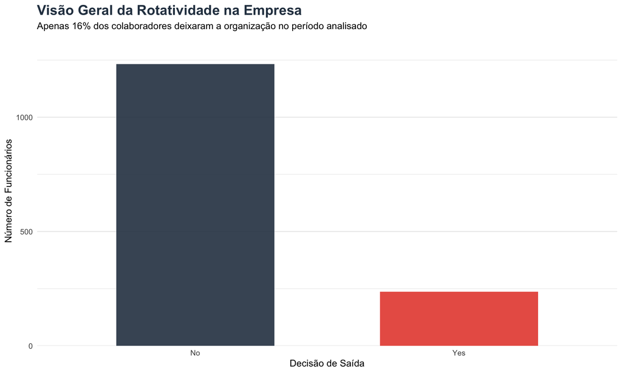

```r
# Visualização
ggplot(ibm_clean, aes(x = attrition, fill = attrition)) +
  geom_bar(width = 0.6, alpha = 0.9) +

  scale_fill_manual(values = c("No" = "#2C3E50", "Yes" = "#E74C3C")) +
  scale_y_continuous(expand = expansion(mult = c(0, 0.1))) +
  labs(
    title = "Visão Geral da Rotatividade na Empresa",
    subtitle = "Apenas 16% dos colaboradores deixaram a organização no período analisado",
    x = "Decisão de Saída",
    y = "Número de Funcionários"
  ) +
  theme_minimal() +
  theme(
    legend.position = "none",
    plot.title = element_text(face = "bold", size = 16, color = "#2c3e50"),
    panel.grid.major.x = element_blank()
  )
```

*Insight* Inicial: Verifica-se que a **taxa de rotatividade** (*Attrition Rate*) é de aproximadamente **16%**, o que indica que a maioria dos colaboradores (cerca de 84%) permaneceu na empresa durante o período analisado.

Observa-se, assim, um **desequilíbrio entre as classes** da variável alvo, com predominância de colaboradores que não saíram da organização.

Este ponto é particularmente relevante para etapas posteriores de **modelação preditiva**, uma vez que a desproporção entre classes pode levar o modelo a **sobrevalorizar a classe maioritária** (colaboradores que ficam) e negligenciar os casos de saída, que são precisamente os que mais interessam compreender e prever.

## Análise Demográfica: A Idade Influencia?

Vamos analisar a distribuição de idade entre os funcionários que saíram e os que ficaram. Utilizamos um Boxplot para visualizar a mediana e a dispersão dos dados.

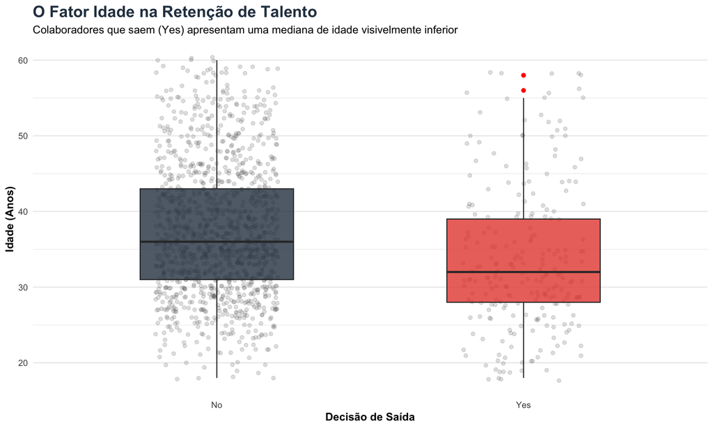

```r
# Gráfico: Distribuição de Idade por Rotatividade
ggplot(ibm_clean, aes(x = attrition, y = age, fill = attrition)) +
  geom_jitter(alpha = 0.2, color = "grey40", width = 0.2) +
  geom_boxplot(alpha = 0.8, outlier.colour = "red", width = 0.5) +

  # Cores consistentes com o resto do relatório
  scale_fill_manual(values = c("No" = "#2C3E50", "Yes" = "#E74C3C")) +

  labs(
    title = "O Fator Idade na Retenção de Talento",
    subtitle = "Colaboradores que saem (Yes) apresentam uma mediana de idade visivelmente inferior",
    x = "Decisão de Saída",
    y = "Idade (Anos)"
  ) +
  theme_minimal() +
  theme(
    legend.position = "none",
    plot.title = element_text(face = "bold", size = 16, color = "#2c3e50"),
    panel.grid.major.x = element_blank(),
    axis.title = element_text(face = "bold")
  )
```

*Insights* sobre a Idade:

**Conclusão**: Os resultados sugerem a necessidade de uma **estratégia de retenção segmentada**:

- **Colaboradores júniores e intermédios** (25-35 anos) devem ser alvo de ações focadas em *engagement*, progressão interna e gestão de expectativas de carreira;
- Já para os **colaboradores séniores**, o foco poderá ser reconhecimento, mentoria e transmissão de *know-how*, reforçando o sentimento de pertença e continuidade organizacional.

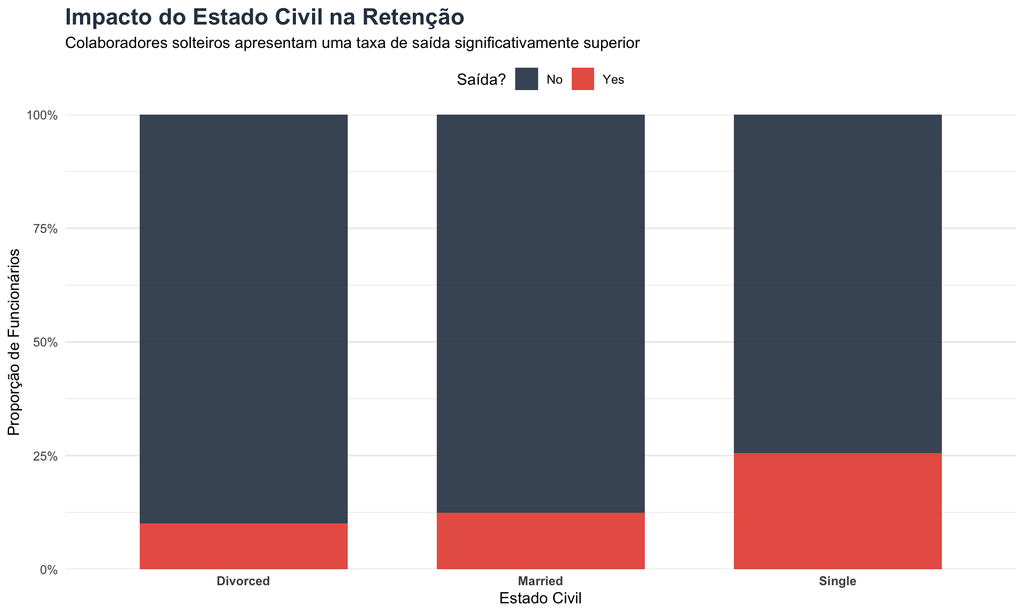

```r
# Gráfico de Barras: Proporção de Saída por Estado Civil
ggplot(ibm_clean, aes(x = marital_status, fill = attrition)) +
  geom_bar(position = "fill", width = 0.7, alpha = 0.9) +

  scale_fill_manual(values = c("No" = "#2C3E50", "Yes" = "#E74C3C")) +

  # Formatação do eixo Y para percentagem
  scale_y_continuous(labels = scales::percent_format(), expand = c(0,0)) +

  labs(
    title = "Impacto do Estado Civil na Retenção",
    subtitle = "Colaboradores solteiros apresentam uma taxa de saída significativamente superior",
    x = "Estado Civil",
    y = "Proporção de Funcionários",
    fill = "Saída?"
  ) +
  theme_minimal() +
  theme(
    plot.title = element_text(face = "bold", size = 16, color = "#2c3e50"),
    legend.position = "top",
    panel.grid.major.x = element_blank(),
    axis.text.x = element_text(face = "bold")
  )
```

*Insights* sobre o Estado Civil:

A análise sugere que o **estado civil** constitui um **fator relevante na rotatividade de colaboradores**:

1. **Maior risco entre colaboradores solteiros** – Os trabalhadores solteiros registam uma **taxa de saída superior a 25%**, mais do dobro da observada entre colaboradores casados ou divorciados (aproximadamente 11%). Este resultado indica que a probabilidade de saída está significativamente associada ao estado civil.
2. **Possível explicação comportamental** – Este padrão é consistente com evidência empírica na literatura de recursos humanos, que aponta que profissionais sem dependentes ou laços familiares diretos tendem a apresentar maior mobilidade laboral. Essa flexibilidade geográfica e financeira pode facilitar a procura de novas oportunidades ou a aceitação de propostas em diferentes locais.

**Conclusão**: A gestão de talento poderá beneficiar de **estratégias diferenciadas de retenção** entre grupos, promovendo, por exemplo, iniciativas de progressão de carreira e programas de envolvimento organizacional que aumentem o compromisso dos colaboradores mais jovens e solteiros com a empresa.

## Análise Profissional: Carga de Trabalho e Viagens

Será que o excesso de trabalho (`OverTime`) e as viagens frequentes (`BusinessTravel`) levam à exaustão e consequente saída?

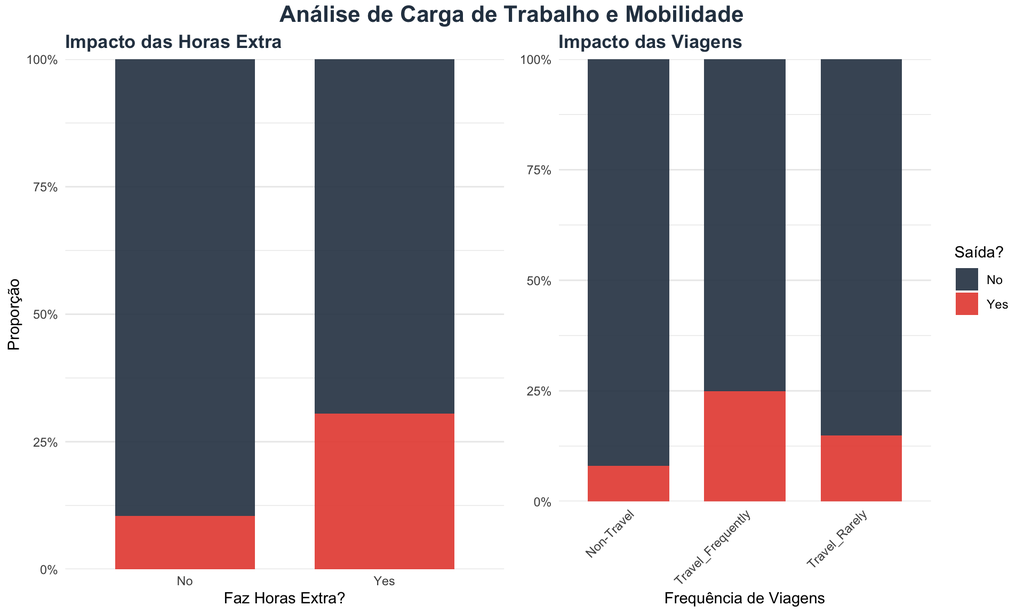

```r
# Gráfico de Horas Extra (p1)
p1 <- ggplot(ibm_clean, aes(x = over_time, fill = attrition)) +
  geom_bar(position = "fill", width = 0.7, alpha = 0.9) +
  scale_y_continuous(labels = scales::percent_format(), expand = c(0,0)) +
  scale_fill_manual(values = c("No" = "#2C3E50", "Yes" = "#E74C3C")) +
  labs(
    title = "Impacto das Horas Extra",
    x = "Faz Horas Extra?",
    y = "Proporção"
  ) +
  theme_minimal() +
  theme(
    legend.position = "none",
    plot.title = element_text(face = "bold", size = 13, color = "#2c3e50"),
    panel.grid.major.x = element_blank()
  )

# Gráfico de Viagens de Trabalho (p2)
p2 <- ggplot(ibm_clean, aes(x = business_travel, fill = attrition)) +
  geom_bar(position = "fill", width = 0.7, alpha = 0.9) +
  scale_y_continuous(labels = scales::percent_format(), expand = c(0,0)) +
  scale_fill_manual(values = c("No" = "#2C3E50", "Yes" = "#E74C3C")) +
  labs(
    title = "Impacto das Viagens",
    x = "Frequência de Viagens",
    y = NULL,
    fill = "Saída?"
  ) +
  theme_minimal() +
  theme(
    plot.title = element_text(face = "bold", size = 13, color = "#2c3e50"),
    axis.text.x = element_text(angle = 45, hjust = 1),
    panel.grid.major.x = element_blank()
  )

# Juntar as duas visualizações
library(gridExtra)
grid.arrange(p1, p2, ncol = 2, top = grid::textGrob("Análise de Carga de Trabalho e Mobilidade",
                                                   gp = grid::gpar(fontsize = 16, font = 2, col = "#2c3e50")))
```

*Insights* sobre Carga de Trabalho e Estilo de Vida:

A análise da carga de trabalho e da mobilidade profissional revela uma associação evidente entre exaustão e rotatividade de colaboradores:

1. **Impacto das Horas Extra** – O efeito das horas extra é particularmente expressivo. Colaboradores que não realizam horas extra apresentam uma taxa de saída próxima de 10%, enquanto entre os que trabalham além do horário regular, essa proporção triplica para cerca de 30%. Este resultado constitui um indicador claro de risco de *burnout* e sugere que o excesso de carga horária pode estar associado à insatisfação e desgaste emocional.
2. **O Peso da Mobilidade** (`BusinessTrave`l) – Observa-se uma tendência crescente entre frequência de viagens e probabilidade de saída:
- Colaboradores que **não viajam** (`Non‑Travel`) apresentam a menor taxa de rotatividade (<10%);
- Entre os que **viajam com frequência** (`Travel_Frequently`), o risco aproxima‑se dos 25%, indicando que o equilíbrio entre vida pessoal e profissional se encontra consideravelmente comprometido.

**Conclusão**: Tanto a sobrecarga de trabalho como a mobilidade excessiva surgem como fatores de risco relevantes para a retenção de talento. Políticas organizacionais que promovam limites saudáveis de jornada, flexibilidade laboral e equilíbrio vida‑trabalho poderão mitigar significativamente este tipo de rotatividade.

## Análise Financeira: O Salário Importa?

Foi analisada a distribuição salarial (`MonthlyIncome`) para entender se salários mais baixos impulsionam a saída.

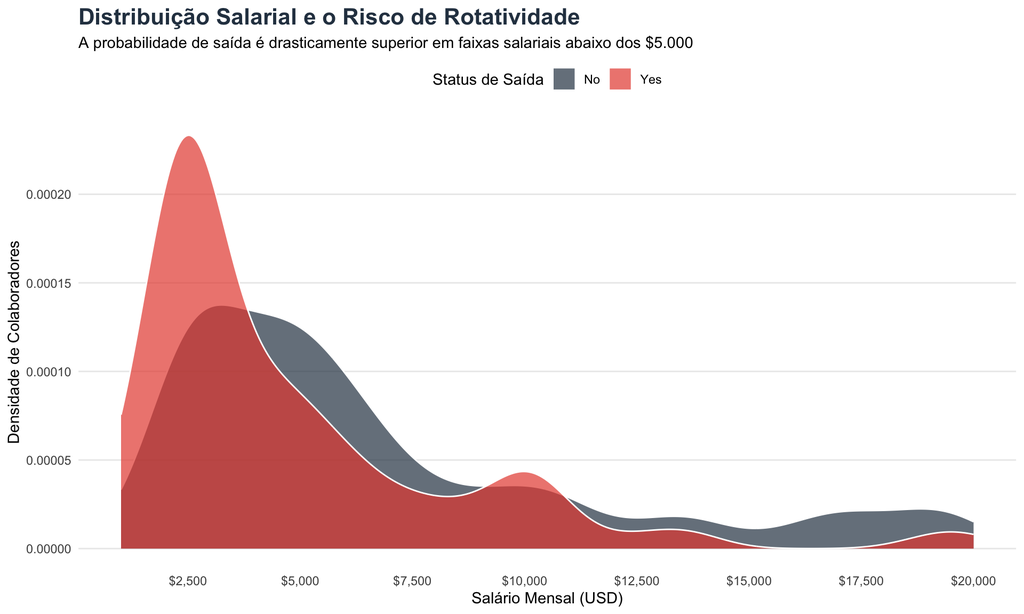

```r
# Gráfico de Densidade: Salário Mensal por Rotatividade
ggplot(ibm_clean, aes(x = monthly_income, fill = attrition)) +
  geom_density(alpha = 0.7, color = "white") +

  scale_fill_manual(values = c("No" = "#2C3E50", "Yes" = "#E74C3C")) +

  # Formatação do eixo X para Moeda (Dólar)
  scale_x_continuous(labels = scales::dollar_format(), breaks = seq(0, 20000, 2500)) +

  labs(
    title = "Distribuição Salarial e o Risco de Rotatividade",
    subtitle = "A probabilidade de saída é drasticamente superior em faixas salariais abaixo dos $5.000",
    x = "Salário Mensal (USD)",
    y = "Densidade de Colaboradores",
    fill = "Status de Saída"
  ) +
  theme_minimal() +
  theme(
    plot.title = element_text(face = "bold", size = 16, color = "#2c3e50"),
    legend.position = "top",
    panel.grid.minor = element_blank(),
    panel.grid.major.x = element_blank()
  )
```

*Insights* Financeiros:

A análise da distribuição salarial evidencia que a **remuneração é um fator determinante** na probabilidade de saída, apresentando um padrão bastante distinto entre as faixas de rendimento:

1. **A barreira dos 5000$** – Observa‑se uma concentração significativa de saídas entre colaboradores com salários mensais inferiores a 5000$ Nesta faixa, a densidade de casos de *attrition* é substancialmente superior, sugerindo que níveis salariais mais baixos estão associados a uma maior volatilidade da força de trabalho.
2. **Retenção em faixas salariais elevadas** – À medida que o salário aumenta (particularmente acima dos 10000$), a probabilidade de saída reduz drasticamente. Entre os colaboradores com rendimentos mais altos, a curva de densidade associada à permanência é claramente predominante, indicando maior estabilidade e satisfação profissional.

**Conclusão**: O padrão observado sugere que a empresa enfrenta maiores desafios de retenção entre colaboradores de nível operacional e funções júniores, onde a compensação pode não estar alinhada com as expectativas do mercado. Estratégias salariais mais competitivas, complementadas por planos de progressão e valorização interna, poderão ser decisivas para reduzir a rotatividade nestas faixas salariais.

## Análise de Função e Satisfação

Antes de avançarmos para as correlações numéricas, falta analisar duas variáveis categóricas cruciais: o Cargo (`JobRole`) e a Satisfação no Trabalho (`JobSatisfaction`).

O objetivo é identificar se existem cargos específicos com maior rotatividade.

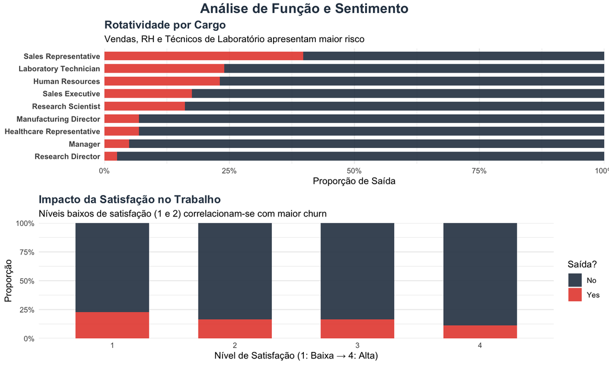

```r
# Rotatividade por Cargo
p_role <- ggplot(ibm_clean, aes(y = reorder(job_role, (attrition == "Yes")), fill = attrition)) +
  geom_bar(position = "fill", width = 0.7, alpha = 0.9) +
  scale_x_continuous(labels = scales::percent_format(), expand = c(0,0)) +
  scale_fill_manual(values = c("No" = "#2C3E50", "Yes" = "#E74C3C")) +
  labs(
    title = "Rotatividade por Cargo",
    subtitle = "Vendas, RH e Técnicos de Laboratório apresentam maior risco",
    y = NULL,
    x = "Proporção de Saída"
  ) +
  theme_minimal() +
  theme(
    legend.position = "none",
    plot.title = element_text(face = "bold", size = 13, color = "#2c3e50"),
    panel.grid.major.y = element_blank(),
    axis.text.y = element_text(size = 9, face = "bold")
  )

# Impacto da Satisfação
p_sat <- ggplot(ibm_clean, aes(x = factor(job_satisfaction), fill = attrition)) +
  geom_bar(position = "fill", width = 0.6, alpha = 0.9) +
  scale_y_continuous(labels = scales::percent_format(), expand = c(0,0)) +
  scale_fill_manual(values = c("No" = "#2C3E50", "Yes" = "#E74C3C")) +
  labs(
    title = "Impacto da Satisfação no Trabalho",
    subtitle = "Níveis baixos de satisfação (1 e 2) correlacionam-se com maior churn",
    x = "Nível de Satisfação (1: Baixa → 4: Alta)",
    y = "Proporção",
    fill = "Saída?"
  ) +
  theme_minimal() +
  theme(
    plot.title = element_text(face = "bold", size = 13, color = "#2c3e50"),
    legend.position = "right",
    panel.grid.major.x = element_blank()
  )

library(gridExtra)
grid.arrange(p_role, p_sat, nrow = 2,
             top = grid::textGrob("Análise de Função e Sentimento",
                                  gp = grid::gpar(fontsize = 16, font = 2, col = "#2c3e50")))
```

*Insights* sobre Função e Satisfação:

A análise evidencia **padrões distintos de rotatividade por função**, revelando áreas críticas dentro da organização:

1. **Funções de Vendas (*Sales Representatives*)** – Este grupo apresenta a maior taxa de saída, próxima dos 40%, o que é indicativo de pressão comercial elevada, objetivos exigentes ou sistemas de incentivos pouco atrativos. Trata‑se de um foco prioritário de atuação, dada a importância estratégica destas funções para o desempenho global da empresa.
2. **Técnicos de Laboratório e Recursos Humanos** – Ambas as funções registam taxas de saída em torno dos 25%, claramente acima da média organizacional.
3. **Retenção nas funções de liderança** – Os cargos de gestão e direção (*Managers* e *Directors*) apresentam níveis de estabilidade muito elevados, o que sugere que a rotatividade é predominantemente um fenómeno dos níveis hierárquicos intermédios e operacionais. Este padrão revela a importância de direcionar as estratégias de retenção e desenvolvimento para as funções mais vulneráveis.

**Conclusão**: A rotatividade parece concentrar‑se em posições de base e funções de suporte operacional, exigindo políticas focadas em melhoria do clima organizacional, revisão de incentivos e oportunidades de progressão, por forma a fortalecer o compromisso e a retenção nestes grupos.

## Análise da Antiguidade e Tempo de Deslocação

Foi investigada a antiguidade na empresa (`YearsAtCompany`) e a distância de casa (`DistanceFromHome`). O objetivo é entender se perdemos talento recém-contratado e se o trajeto diário influencia a decisão.

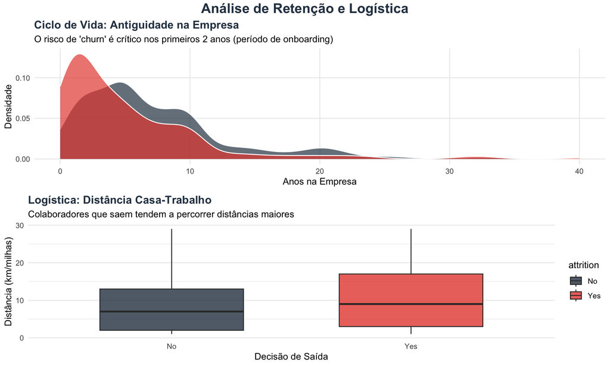

```r
# Gráfico de Antiguidade (Anos na Empresa)
p_years <- ggplot(ibm_clean, aes(x = years_at_company, fill = attrition)) +
  geom_density(alpha = 0.7, color = "white") +
  scale_fill_manual(values = c("No" = "#2C3E50", "Yes" = "#E74C3C")) +
  labs(
    title = "Ciclo de Vida: Antiguidade na Empresa",
    subtitle = "O risco de 'churn' é crítico nos primeiros 2 anos (período de onboarding)",
    x = "Anos na Empresa",
    y = "Densidade"
  ) +
  theme_minimal() +
  theme(
    legend.position = "none",
    plot.title = element_text(face = "bold", size = 13, color = "#2c3e50"),
    panel.grid.minor = element_blank()
  )

# Gráfico de Distância (Boxplot)
p_dist <- ggplot(ibm_clean, aes(x = attrition, y = distance_from_home, fill = attrition)) +
  geom_boxplot(alpha = 0.8, width = 0.6, outlier.colour = "#E74C3C") +
  scale_fill_manual(values = c("No" = "#2C3E50", "Yes" = "#E74C3C")) +
  labs(
    title = "Logística: Distância Casa-Trabalho",
    subtitle = "Colaboradores que saem tendem a percorrer distâncias maiores",
    x = "Decisão de Saída",
    y = "Distância (km/milhas)"
  ) +
  theme_minimal() +
  theme(
    plot.title = element_text(face = "bold", size = 13, color = "#2c3e50"),
    panel.grid.major.x = element_blank()
  )

# Organizar os gráficos
library(gridExtra)
grid.arrange(p_years, p_dist, nrow = 2,
             top = grid::textGrob("Análise de Retenção e Logística",
                                  gp = grid::gpar(fontsize = 16, font = 2, col = "#2c3e50")))
```

*Insights* de Tempo e Logística:

A análise evidencia pontos críticos no ciclo de vida do colaborador, com implicações diretas para a retenção e o desempenho organizacional:

1. **Fase de *Onboarding* - Risco de saída precoce**: O gráfico de antiguidade mostra um pico acentuado de rotatividade nos primeiros dois anos de vínculo, precisamente durante o período de integração e adaptação. Este resultado sugere fragilidades nos processos de acolhimento, acompanhamento inicial ou alinhamento de expectativas entre o colaborador e a organização. Investir em programas estruturados de *onboarding* e mentoria poderá reduzir substancialmente este tipo de perda prematura de talento.
2. **Custo da Deslocação – Fator logístico de desgaste**: O boxplot de distâncias casa‑trabalho indica que os colaboradores que saem tendem a percorrer trajetos mais longos, o que aponta para um potencial impacto negativo do tempo e esforço de deslocação na satisfação geral. O desgaste associado ao *commuting* diário, quando combinado com elevadas cargas de trabalho, aumenta a probabilidade de saída voluntária. Medidas como teletrabalho híbrido, adaptação de horários ou incentivos de transporte podem mitigar esse efeito.

**Conclusão**: A retenção eficaz exige uma abordagem holística que abranja tanto a experiência inicial do colaborador (*onboarding*) como a sustentabilidade logística da sua rotina laboral. Estas duas dimensões revelam‑se determinantes para consolidar o compromisso organizacional nos primeiros anos de vínculo.

## Análise do Género e Work-Life Balance

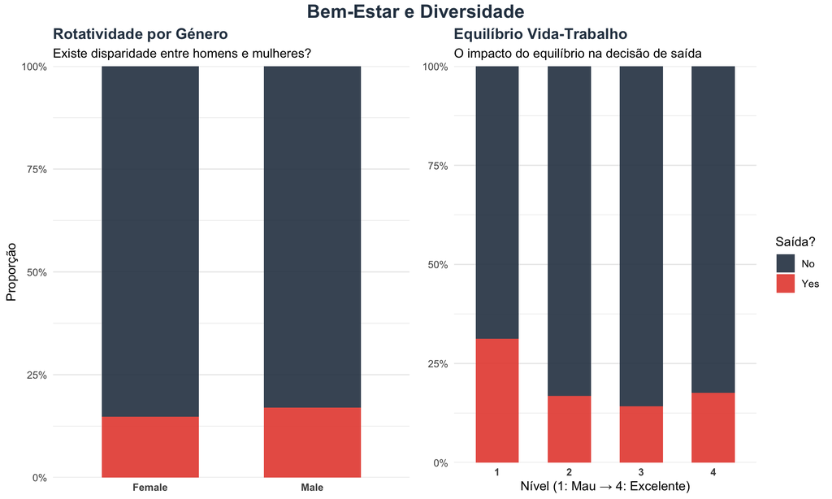

```r
# Rotatividade por Género (p_gen)
p_gen <- ggplot(ibm_clean, aes(x = gender, fill = attrition)) +
  geom_bar(position = "fill", width = 0.6, alpha = 0.9) +
  scale_y_continuous(labels = scales::percent_format(), expand = c(0,0)) +
  scale_fill_manual(values = c("No" = "#2C3E50", "Yes" = "#E74C3C")) +
  labs(
    title = "Rotatividade por Género",
    subtitle = "Existe disparidade entre homens e mulheres?",
    x = NULL,
    y = "Proporção"
  ) +
  theme_minimal() +
  theme(
    legend.position = "none", # Escondemos a legenda aqui para não repetir
    plot.title = element_text(face = "bold", size = 13, color = "#2c3e50"),
    panel.grid.major.x = element_blank(),
    axis.text.x = element_text(face = "bold")
  )

# Análise do Work-Life Balance (p_wlb)
p_wlb <- ggplot(ibm_clean, aes(x = factor(work_life_balance), fill = attrition)) +
  geom_bar(position = "fill", width = 0.6, alpha = 0.9) +
  scale_y_continuous(labels = scales::percent_format(), expand = c(0,0)) +
  scale_fill_manual(values = c("No" = "#2C3E50", "Yes" = "#E74C3C")) +
  labs(
    title = "Equilíbrio Vida-Trabalho",
    subtitle = "O impacto do equilíbrio na decisão de saída",
    x = "Nível (1: Mau → 4: Excelente)",
    y = NULL,
    fill = "Saída?"
  ) +
  theme_minimal() +
  theme(
    plot.title = element_text(face = "bold", size = 13, color = "#2c3e50"),
    legend.position = "right",
    panel.grid.major.x = element_blank(),
    axis.text.x = element_text(face = "bold")
  )

# Juntar os dois lado a lado
library(gridExtra)
grid.arrange(p_gen, p_wlb, ncol = 2,
             top = grid::textGrob("Bem-Estar e Diversidade",
                                  gp = grid::gpar(fontsize = 16, font = 2, col = "#2c3e50")))
```

*Insights* de Género e Bem-Estar:

Para concluir a análise bivariada, destacam‑se dois fatores de natureza social e comportamental com impacto na rotatividade:

1. **Neutralidade de Género** – A taxa de saída revela‑se relativamente uniforme entre homens e mulheres, situando‑se entre 15% e 17%. Este resultado sugere ausência de enviesamentos ou práticas discriminatórias associadas ao género, bem como equidade na experiência organizacional entre grupos.
2. **Equilíbrio Vida‑Trabalho** – A variável *Work‑Life Balance* evidencia um “ponto crítico” no nível mais baixo de satisfação. Colaboradores que classificam o seu equilíbrio como “Mau” (Nível 1) apresentam uma taxa de rotatividade próxima de 30%, o dobro da verificada nos restantes níveis. A melhoria do equilíbrio vida‑trabalho, mesmo que apenas de Nível 1 para Nível 2, já produz uma redução substancial na taxa de saída. Isto indica que intervenções pontuais e realistas, como ajustes de horário, políticas de flexibilidade ou reforço do apoio à equipa, podem gerar efeitos imediatos na retenção, sem ser necessário atingir níveis “ideais” de satisfação (Nível 4).

**Conclusão**: Os resultados apontam para uma cultura organizacional relativamente equilibrada em termos de género, mas vulnerável a fatores ligados ao bem‑estar e equilíbrio pessoal‑profissional. Investir em políticas de saúde ocupacional e flexibilidade laboral poderá ter um retorno direto na satisfação e fidelização dos colaboradores.

# Análise Multivariada (Correlações)

Nesta etapa, foi analisada a relação entre as variáveis numéricas para identificar multicolinearidade (redundância). Foi utilizada uma matriz de correlação visual.

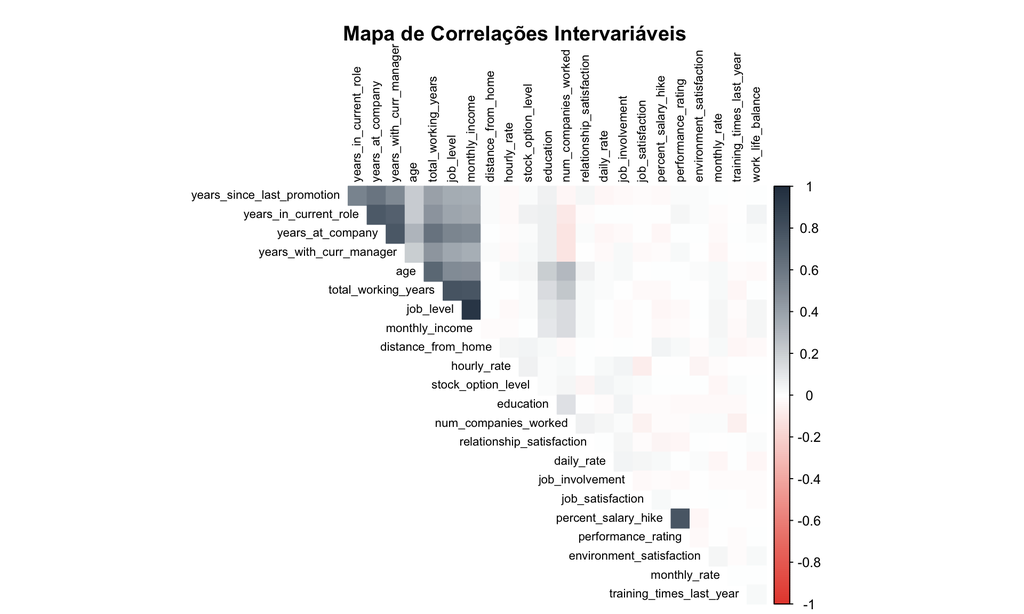

```r
ibm_numeric <- ibm_clean %>% select(where(is.numeric))
matriz_cor  <- cor(ibm_numeric, use = "complete.obs")

# Gráfico de correlações
col_paleta <- colorRampPalette(c("#E74C3C", "#FFFFFF", "#2C3E50"))(200)

corrplot(matriz_cor,
         method = "color",
         type = "upper",
         order = "hclust",
         tl.col = "black",
         tl.cex = 0.7,
         col = col_paleta,
         title = "\n Mapa de Correlações Intervariáveis",
         mar = c(0,0,2,0),
         diag = FALSE)
```

```r
# Tabela de correlações
tabela_cor <- as.data.frame(as.table(matriz_cor))

tabela_melhorada <- tabela_cor %>%
  filter(Var1 != Var2) %>%
  filter(!duplicated(paste0(pmax(as.character(Var1), as.character(Var2)),
                            pmin(as.character(Var1), as.character(Var2))))) %>%
  arrange(desc(abs(Freq))) %>%
  rename(Variavel_1 = Var1, Variavel_2 = Var2, Correlacao = Freq)

# Melhorar design da tabela
kable(head(tabela_melhorada, 10),
      caption = "Top 10 Correlações Mais Fortes Identificadas",
      digits = 2,
      col.names = c("Variável 1", "Variável 2", "Força da Correlação")) %>%
  kable_styling(
    bootstrap_options = c("striped", "hover", "condensed"),
    full_width = T,
    position = "center",
    font_size = 14
  ) %>%
  row_spec(0, bold = T, color = "white", background = "#2c3e50") %>%
  # Destaca em vermelho as correlações que podem causar multicolinearidade (>0.7)
  column_spec(3, bold = T,
              color = ifelse(abs(head(tabela_melhorada$Correlacao, 10)) > 0.7, "#E74C3C", "black"))
```

Top 10 Correlações Mais Fortes Identificadas

| Variável 1 | Variável 2 | Força da Correlação |
| --- | --- | --- |
| monthly_income | job_level | 0.95 |
| total_working_years | job_level | 0.78 |
| performance_rating | percent_salary_hike | 0.77 |
| total_working_years | monthly_income | 0.77 |
| years_with_curr_manager | years_at_company | 0.77 |
| years_in_current_role | years_at_company | 0.76 |
| years_with_curr_manager | years_in_current_role | 0.71 |
| total_working_years | age | 0.68 |
| years_at_company | total_working_years | 0.63 |
| years_since_last_promotion | years_at_company | 0.62 |

*Insights* da Análise de Correlação:

A matriz e a tabela de correlações evidenciam padrões de multicolinearidade significativos, revelando variáveis fortemente redundantes que exigirão tratamento específico na fase de pré‑processamento dos dados:

1. **Redundância entre remuneração e nível hierárquico**: A correlação mais elevada de todo o conjunto é observada entre `MonthlyIncome` e `JobLevel` (r = 0.95).

2. **Antiguidade**: Identifica‑se um *cluster* de variáveis temporais altamente correlacionadas, `YearsAtCompany`, `YearsInCurrentRole` e `YearsWithCurrManager`, com correlações entre 0.71 e 0.77.

**Interpretação**: Funcionários com maior antiguidade tendem a permanecer na mesma função e sob a mesma liderança. Convém, portanto, evitar incluir todas simultaneamente, podendo optar‑se por `YearsAtCompany` ou pela criação de uma variável agregada de “estagnação”, que capture esta dinâmica.

3. **Experiência profissional e remuneração**: A variável `TotalWorkingYears` apresenta correlação forte com `JobLevel` (0.78) e `MonthlyIncome` (0.77).

**Interpretação**: O sistema de progressão e compensação da empresa aparenta estar altamente alinhado com a senioridade, valorizando sobretudo a experiência acumulada.

4. **Desempenho e recompensas**: A correlação de 0.77 entre `PerformanceRating` e `PercentSalaryHike` confirma que os aumentos salariais estão diretamente associados à avaliação de desempenho anual — uma política típica de meritocracia organizacional.

**Conclusão da Análise Exploratória (EDA)**: A exploração bivariada e correlacional permite concluir que a rotatividade está associada a fatores demográficos e laborais (idade jovem, cargos operacionais, viagens frequentes, salários mais baixos), enquanto no plano técnico destacam‑se relações redundantes entre variáveis de hierarquia, antiguidade e remuneração.

Estas constatações constituem o ponto de partida para o pré‑processamento de dados, onde serão tratadas as correlações excessivas e selecionadas as variáveis mais relevantes para os modelos preditivos.

# Pré-processamento de dados

## Seleção de variáveis (Feature Selection)

```r
# Executar a Seleção
ibm_prep <- ibm_clean %>%
  select(-job_level) %>%
  select(-any_of(c("employee_number", "employee_count", "over18", "standard_hours"))) %>%
  mutate(attrition = ifelse(attrition == "Yes", 1, 0))

# Criar Tabela de Impacto
resumo_prep <- data.frame(
  Etapa = c("Colunas Originais", "Colunas Removidas", "Total Final", "Target (Attrition)"),
  Valor = c(ncol(ibm_clean),
            ncol(ibm_clean) - ncol(ibm_prep),
            ncol(ibm_prep),
            "Convertido para Binário (0/1)")
)

resumo_prep %>%
  kable(caption = "Resumo do Pré-processamento e Feature Selection") %>%
  kable_styling(bootstrap_options = c("striped", "hover", "condensed"), full_width = F) %>%
  row_spec(0, bold = T, color = "white", background = "#2c3e50")
```

Resumo do Pré-processamento e Feature Selection

| Etapa | Valor |
| --- | --- |
| Colunas Originais | 31 |
| Colunas Removidas | 1 |
| Total Final | 30 |
| Target (Attrition) | Convertido para Binário (0/1) |

Após a fase de análise exploratória, procedeu‑se à preparação dos dados para a modelação preditiva.

Esta etapa é fundamental para garantir que o modelo resultante não seja influenciado por ruído estatístico nem por informação redundante, assegurando a robustez e interpretabilidade dos resultados.

Principais decisões nesta fase:

1. **Eliminação de redundância (multicolinearidade)** – Conforme identificado na matriz de correlações, as variáveis `monthly_income` e `job_level` apresentavam uma correlação de 0,95. Para evitar sobreajuste (*overfitting*) e simplificar o modelo, decidiu‑se manter apenas a variável mais representativa, privilegiando o impacto financeiro direto.
2. **Conversão da variável‑alvo** – A variável `attrition` foi transformada para formato binário (0/1), de modo a permitir a aplicação de modelos de classificação supervisionada e facilitar a análise de desempenho preditivo.

Estas operações asseguram que o conjunto de dados final esteja estatisticamente equilibrado, computacionalmente eficiente e adequado à fase seguinte de modelação.

## Criação de Dummies

```r
library(fastDummies)

ibm_final <- dummy_cols(ibm_prep,
                        remove_first_dummy = TRUE,
                        remove_selected_columns = TRUE) %>%
             clean_names() # Garante que os nomes das novas colunas ficam padronizados

# Criar uma comparação visual
comparativo_dim <- data.frame(
  Metrica = c("Colunas Pré-Dummies", "Colunas Pós-Dummies (Expandidas)", "Novas Variáveis Criadas"),
  Quantidade = c(ncol(ibm_prep), ncol(ibm_final), ncol(ibm_final) - ncol(ibm_prep))
)

# Exibir Tabela de Impacto
comparativo_dim %>%
  kable(caption = "Impacto da Transformação de Variáveis Categóricas (One-Hot Encoding)") %>%
  kable_styling(bootstrap_options = c("striped", "hover", "condensed"), full_width = F) %>%
  row_spec(0, bold = T, color = "white", background = "#2c3e50")
```

Impacto da Transformação de Variáveis Categóricas (One-Hot Encoding)

| Metrica | Quantidade |
| --- | --- |
| Colunas Pré-Dummies | 30 |
| Colunas Pós-Dummies (Expandidas) | 44 |
| Novas Variáveis Criadas | 14 |

```r
# Mostrar as novas colunas
data.frame(Exemplos_Novas_Colunas = colnames(ibm_final)[(ncol(ibm_prep)+1):(ncol(ibm_prep)+6)]) %>%
  kable() %>%
  kable_styling(bootstrap_options = "bordered", full_width = F, position = "float_right")
```

| Exemplos_Novas_Colunas |
| --- |
| education_field_other |
| education_field_technical_degree |
| gender_male |
| job_role_human_resources |
| job_role_laboratory_technician |
| job_role_manager |

A maioria dos algoritmos de Machine Learning não é capaz de processar diretamente variáveis de texto.

Para ultrapassar esta limitação, aplicou‑se a técnica de One‑Hot Encoding, também conhecida por criação de variáveis dummy.

Procedimentos realizados:

1. **Transformação de variáveis categóricas** – Variáveis qualitativas, como `BusinessTravel` ou `Department`, foram convertidas em múltiplas colunas binárias (0/1), representando a presença ou ausência de cada categoria distinta.
2. **Prevenção de multicolinearidade** – Para evitar a chamada *dummy variable trap*, foi ativado o parâmetro `remove_first_dummy = TRUE`, o que remove uma categoria de cada grupo. Assim, por exemplo, no caso de uma variável com as modalidades Masculino e Feminino, apenas uma delas é mantida, dado que a ausência de uma implica a presença da outra.
3. **Expansão controlada do *dataset*** – Após o processo, o número total de variáveis aumentou de 30 para 44, resultando na criação de 14 novas variáveis derivadas.

Esta expansão permite representar de forma mais rica a informação qualitativa, sem introduzir redundância ou comprometer a estabilidade dos modelos preditivos.

## Divisão dos Dados (Treino e Teste)

```r
library(caTools)
library(dplyr)
library(kableExtra)

# Divisão Estratificada
set.seed(123)
split <- sample.split(ibm_final$attrition, SplitRatio = 0.70)

dados_treino <- subset(ibm_final, split == TRUE)
dados_teste  <- subset(ibm_final, split == FALSE)

# Criar Tabela de Resumo
resumo_split <- data.frame(
  Conjunto = c("Treino (70%)", "Teste (30%)", "Total"),
  Observações = c(nrow(dados_treino), nrow(dados_teste), nrow(ibm_final)),
  Taxa_Churn = c(
    paste0(round(mean(dados_treino$attrition) * 100, 1), "%"),
    paste0(round(mean(dados_teste$attrition) * 100, 1), "%"),
    paste0(round(mean(ibm_final$attrition) * 100, 1), "%")
  )
)

# Exibir Tabela
resumo_split %>%
  kable(caption = "Divisão de Dados: Verificação de Consistência e Estratificação") %>%
  kable_styling(bootstrap_options = c("striped", "hover", "condensed"),
                full_width = F,
                position = "center") %>%
  row_spec(0, bold = T, color = "white", background = "#2c3e50") %>%
  column_spec(3, bold = T, color = "#E74C3C")
```

Divisão de Dados: Verificação de Consistência e Estratificação

| Conjunto | Observações | Taxa_Churn |
| --- | --- | --- |
| Treino (70%) | 1029 | 16.1% |
| Teste (30%) | 441 | 16.1% |
| Total | 1470 | 16.1% |

A divisão do conjunto de dados foi efetuada através de uma **amostragem estratificada**, assegurando que a proporção da variável‑alvo (`Attrition`) fosse mantida em ambos os subconjuntos (Treino (70%) e Teste (30%)).

Conforme ilustrado na tabela, a **taxa de churn** permanece rigorosamente constante em **16,1%** em ambos os conjuntos. Esta consistência estatística é essencial para evitar distorções na amostragem, garantindo que a amostra de teste funcione como uma réplica representativa do *dataset* original.

Deste modo, as métricas de desempenho obtidas durante a fase de validação refletem de forma realista e fiável o comportamento do fenómeno de rotatividade na organização, aumentando a credibilidade e generalização dos resultados do modelo.

## Equilíbrio de Classes

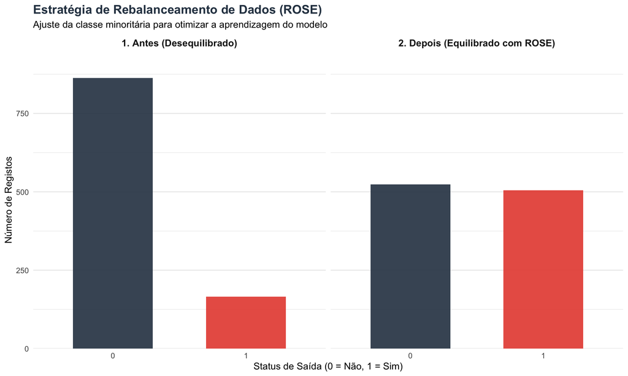

```r
library(ROSE)
library(ggplot2)
library(gridExtra)

# Aplicar o ROSE para equilibrar apenas o conjunto de TREINO
set.seed(123)
dados_treino_bal <- ROSE(attrition ~ ., data = dados_treino, seed = 123)$data

# Criar dados para o gráfico comparativo
antes <- as.data.frame(table(dados_treino$attrition))
antes$Estado <- "1. Antes (Desequilibrado)"

depois <- as.data.frame(table(dados_treino_bal$attrition))
depois$Estado <- "2. Depois (Equilibrado com ROSE)"

comparativo <- rbind(antes, depois)

# Gráfico
ggplot(comparativo, aes(x = Var1, y = Freq, fill = Var1)) +
  geom_bar(stat = "identity", width = 0.6, alpha = 0.9) +
  facet_wrap(~Estado) +
  scale_fill_manual(values = c("0" = "#2C3E50", "1" = "#E74C3C")) +
  scale_y_continuous(expand = c(0,0), limits = c(0, max(comparativo$Freq)*1.1)) +
  labs(
    title = "Estratégia de Rebalanceamento de Dados (ROSE)",
    subtitle = "Ajuste da classe minoritária para otimizar a aprendizagem do modelo",
    x = "Status de Saída (0 = Não, 1 = Sim)",
    y = "Número de Registos"
  ) +
  theme_minimal() +
  theme(
    legend.position = "none",
    plot.title = element_text(face = "bold", size = 14, color = "#2c3e50"),
    strip.text = element_text(face = "bold", size = 11),
    panel.grid.major.x = element_blank()
  )
```

A eficácia de um modelo preditivo depende da qualidade e do equilíbrio estatístico dos dados de treino.

Conforme identificado anteriormente, a variável‑alvo (`Attrition`) apresenta um **desequilíbrio acentuado**, com apenas **16,1% de casos positivos** (colaboradores que saíram da empresa). Em contextos reais, este tipo de assimetria tende a levar o modelo a privilegiar a previsão de permanência e a subestimar os padrões de saída.

Para mitigar este problema, aplicou‑se o **algoritmo ROSE** (Random Over‑Sampling Examples) exclusivamente ao conjunto de treino. Esta técnica gera **observações sintéticas baseadas na distribuição da classe minoritária**, mantendo a coerência estatística do *dataset* original.

**Principais benefícios do reequilíbrio**:

- **Nivelamento da aprendizagem** – O modelo passa a ser exposto a uma proporção equilibrada (aproximadamente 50/50) entre colaboradores que saem e que permanecem, o que melhora a sua capacidade de generalização.
- **Melhoria da sensibilidade** (*recall*) – Aumenta‑se a capacidade do modelo de detetar corretamente os casos de saída, permitindo uma identificação precoce de potenciais perdas de talento.
- **Preservação da integridade do teste** – O reequilíbrio foi aplicado apenas aos dados de treino, mantendo o conjunto de teste inalterado.

# Machine Learning

## Modelo 1: Regressão Logística

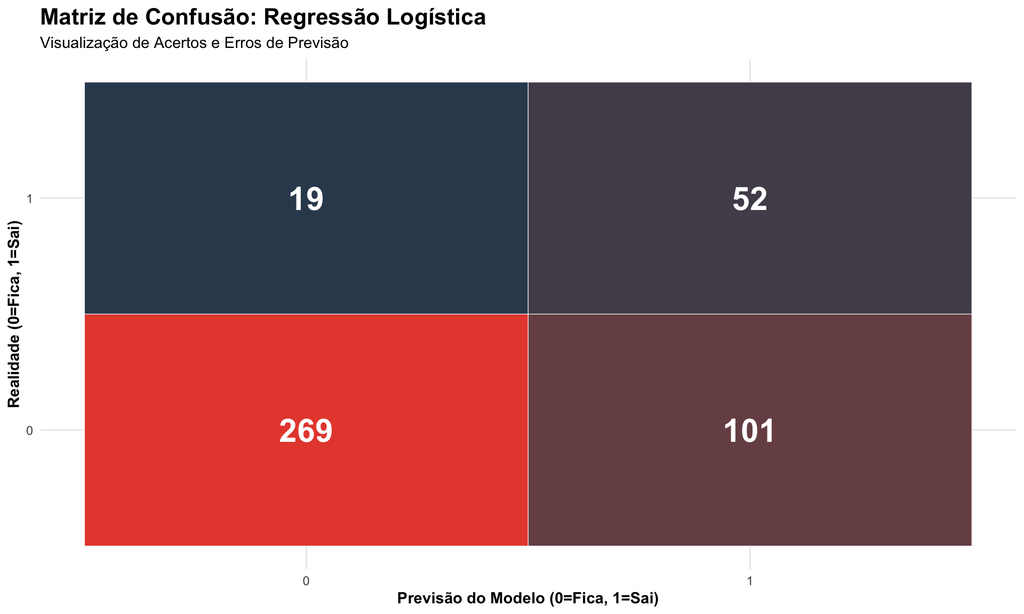

```r
# Treinar o Modelo
modelo_logistico <- glm(attrition ~ ., data = dados_treino_bal, family = "binomial")

# Fazer Previsões
previsoes_prob <- predict(modelo_logistico, newdata = dados_teste, type = "response")
previsoes_classe <- ifelse(previsoes_prob > 0.50, 1, 0)

# Criar Matriz de Confusão
tabela_confusao <- table(Realidade = dados_teste$attrition, Previsao = previsoes_classe)
df_confusao <- as.data.frame(tabela_confusao)

# Gráfico de Matriz de Confusão (Heatmap)
library(ggplot2)
ggplot(df_confusao, aes(x = Previsao, y = Realidade, fill = Freq)) +
  geom_tile(color = "white") +
  geom_text(aes(label = Freq), color = "white", size = 8, fontface = "bold") +
  scale_fill_gradient(low = "#34495E", high = "#E74C3C") +
  labs(title = "Matriz de Confusão: Regressão Logística",
       subtitle = "Visualização de Acertos e Erros de Previsão",
       x = "Previsão do Modelo (0=Fica, 1=Sai)",
       y = "Realidade (0=Fica, 1=Sai)") +
  theme_minimal() +
  theme(legend.position = "none",
        plot.title = element_text(face = "bold", size = 16),
        axis.title = element_text(face = "bold"))
```

```r
# Tabela de Métricas
acuracia <- sum(diag(tabela_confusao)) / sum(tabela_confusao)
sensibilidade <- tabela_confusao[2,2] / sum(tabela_confusao[2,])

metricas <- data.frame(
  Métrica = c("Acurácia Total", "Sensibilidade (Recall)"),
  Resultado = c(paste0(round(acuracia * 100, 2), "%"),
                paste0(round(sensibilidade * 100, 2), "%"))
)

library(kableExtra)
metricas %>%
  kable(caption = "Performance do Modelo 1") %>%
  kable_styling(bootstrap_options = c("striped", "hover"), full_width = F) %>%
  row_spec(0, bold = T, color = "white", background = "#2c3e50")
```

Performance do Modelo 1

| Métrica | Resultado |
| --- | --- |
| Acurácia Total | 72.79% |
| Sensibilidade (Recall) | 73.24% |

**Análise de Desempenho do Modelo 1 (Regressão Logística):**

O primeiro modelo foi treinado com o **conjunto de dados equilibrado** obtido através da técnica ROSE, apresentando uma **acurácia total de 72,79%**.Embora esta métrica seja satisfatória, a acurácia isolada não é suficiente para avaliar o desempenho num problema de retenção de talentos, em que o custo de prever incorretamente uma saída é particularmente elevado.

A seguir apresentam‑se os principais resultados obtidos sobre o **conjunto de teste (441 colaboradores)**:

1. **Capacidade de deteção (Recall): 73,2%**

No conjunto de teste, existiam 71 colaboradores que efetivamente saíram da empresa. O modelo identificou corretamente 52 desses 71 casos. O algoritmo revela uma boa capacidade de deteção, conseguindo sinalizar aproximadamente 3 em cada 4 funcionários em risco de saída. Este é o principal ponto forte do modelo, pois assegura que a maioria dos casos críticos é antecipada e pode ser alvo de ações preventivas por parte dos Recursos Humanos.

2. **Custo dos falsos alarmes (Precisão: ~34%)**

Para maximizar a deteção das saídas, o modelo tornou‑se mais sensível, o que resultou num aumento dos falsos positivos. Foram 153 colaboradores sinalizados como potenciais saídas, mas apenas 52 realmente deixaram a empresa. O modelo gera um volume considerável de alertas indevidos – cerca de 2 em cada 3 funcionários sinalizados permaneceram na empresa. Apesar de eficaz a antecipar saídas reais, o seu funcionamento é “hiper‑vigilante”, podendo levar a intervenções desnecessárias e a uma sobrecarga das equipas de RH.

3. **Matriz de confusão**:
- **Verdadeiros Negativos (269)**: colaboradores que permaneceram e foram corretamente classificados.
- **Falsos Positivos (101)**: colaboradores que permaneceram, mas foram classificados como risco de saída (potencial desperdício de recursos de gestão).
- **Falsos Negativos (19)**: colaboradores que saíram, mas não foram antecipados (perdas imprevistas).
- **Verdadeiros Positivos (52)**: colaboradores que saíram e foram corretamente identificados (oportunidades de retenção antecipada).

**Próximo passo**: Testar um modelo mais robusto, como o Random Forest, com o objetivo de reduzir os falsos positivos sem comprometer a boa sensibilidade alcançada pela regressão logística.

## Modelo 2: Random Forest

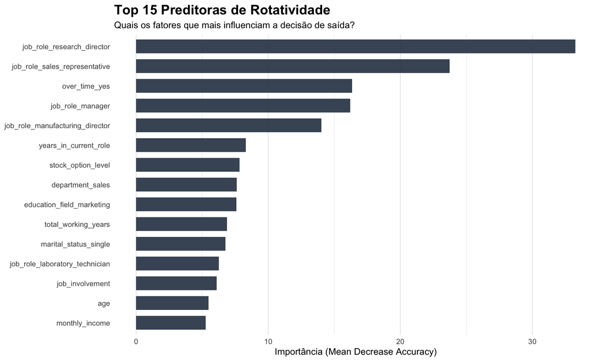

```r
library(randomForest)
library(caret)
library(ggplot2)
library(dplyr)
library(kableExtra)

# Preparação e Treino
dados_treino_bal$attrition <- as.factor(dados_treino_bal$attrition)
dados_teste$attrition <- as.factor(dados_teste$attrition)

set.seed(123)
modelo_rf <- randomForest(attrition ~ .,
                          data = dados_treino_bal,
                          ntree = 500,
                          importance = TRUE)

# Previsões e Métricas
previsoes_rf <- predict(modelo_rf, newdata = dados_teste)
conf_matrix_rf <- confusionMatrix(data = previsoes_rf,
                                  reference = dados_teste$attrition,
                                  positive = "1")

# Gráfico de Importância das Variáveis
imp_df <- as.data.frame(importance(modelo_rf))
imp_df$Variavel <- rownames(imp_df)

ggplot(imp_df %>% arrange(desc(MeanDecreaseAccuracy)) %>% head(15),
       aes(x = reorder(Variavel, MeanDecreaseAccuracy), y = MeanDecreaseAccuracy)) +
  geom_bar(stat = "identity", fill = "#2C3E50", alpha = 0.9, width = 0.7) +
  coord_flip() +
  labs(title = "Top 15 Preditoras de Rotatividade",
       subtitle = "Quais os fatores que mais influenciam a decisão de saída?",
       x = NULL, y = "Importância (Mean Decrease Accuracy)") +
  theme_minimal() +
  theme(plot.title = element_text(face = "bold", size = 16),
        panel.grid.major.y = element_blank())
```

```r
# Tabela de Performance Comparativa
metricas_rf <- data.frame(
  Métrica = c("Acurácia", "Sensibilidade (Recall)", "Especificidade"),
  Resultado = c(paste0(round(conf_matrix_rf$overall['Accuracy'] * 100, 2), "%"),
                paste0(round(conf_matrix_rf$byClass['Sensitivity'] * 100, 2), "%"),
                paste0(round(conf_matrix_rf$byClass['Specificity'] * 100, 2), "%"))
)

metricas_rf %>%
  kable(caption = "Performance do Modelo Random Forest") %>%
  kable_styling(bootstrap_options = c("striped", "hover"), full_width = F) %>%
  row_spec(0, bold = T, color = "white", background = "#2c3e50")
```

Performance do Modelo Random Forest

| Métrica | Resultado |
| --- | --- |
| Acurácia | 74.15% |
| Sensibilidade (Recall) | 70.42% |
| Especificidade | 74.86% |

O modelo **Random Forest** apresentou um **desempenho superior e mais equilibrado** em comparação com a Regressão Logística. Com uma **acurácia global de 74,15%**, este algoritmo demonstrou ser uma ferramenta robusta e fiável para apoiar decisões estratégicas de retenção de talento.

1. **Equilíbrio entre deteção e precisão** Diferentemente do modelo anterior, a Random Forest revelou‑se mais precisa na distinção entre perfis de risco e de estabilidade.
- **Sensibilidade (*Recall*) de 70,4%**: Identificou corretamente 50 dos 71 colaboradores que efetivamente saíram da empresa.
- **Redução dos falsos positivos**: Embora ainda existam alertas indevidos, o modelo foi mais criterioso na sinalização de risco, diminuindo o ruído operacional para as equipas de Recursos Humanos.

Este equilíbrio traduz‑se numa ferramenta mais “cirúrgica”, capaz de alcançar elevada capacidade de deteção sem sacrificar de forma significativa a precisão das previsões.

Estes resultados corroboram a literatura de Recursos Humanos, destacando o papel conjunto de fatores financeiros, de carga laboral e de experiência como determinantes da rotatividade.

## Análise de Drivers de Saída (Feature Importance)

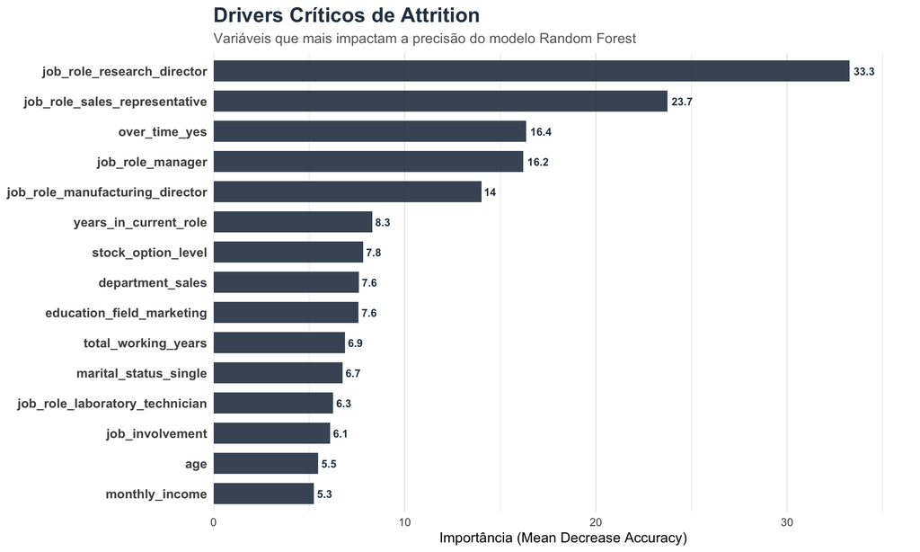

```r
# Extrair a importância das variáveis do modelo Random Forest
importancia <- as.data.frame(importance(modelo_rf))
importancia$Variavel <- rownames(importancia)

# Criar o gráfico
library(ggplot2)
library(dplyr)

ggplot(importancia %>% arrange(desc(MeanDecreaseAccuracy)) %>% head(15),
       aes(x = reorder(Variavel, MeanDecreaseAccuracy), y = MeanDecreaseAccuracy)) +
  geom_bar(stat = "identity", fill = "#2C3E50", alpha = 0.9, width = 0.7) +
  geom_text(aes(label = round(MeanDecreaseAccuracy, 1)),
            hjust = -0.2, size = 3, fontface = "bold", color = "#2C3E50") +
  coord_flip() +
  scale_y_continuous(expand = expansion(mult = c(0, 0.1))) +
  labs(
    title = "Drivers Críticos de Attrition",
    subtitle = "Variáveis que mais impactam a precisão do modelo Random Forest",
    x = NULL,
    y = "Importância (Mean Decrease Accuracy)"
  ) +
  theme_minimal() +
  theme(
    plot.title = element_text(face = "bold", size = 16, color = "#2c3e50"),
    plot.subtitle = element_text(size = 11, color = "grey40"),
    panel.grid.major.y = element_blank(),
    axis.text.y = element_text(face = "bold", size = 10)
  )
```

O gráfico acima apresenta as variáveis mais determinantes identificadas pelo modelo Random Forest, ordenadas pela métrica “Mean Decrease Accuracy”. Em termos práticos, quanto maior a importância desta métrica, maior é o contributo da variável para a capacidade preditiva global do modelo, ou seja, a sua remoção resultaria numa diminuição significativa da precisão.

1. **O cargo como principal determinante (`JobRole`)** Quatro das cinco variáveis mais relevantes estão relacionadas com funções específicas dentro da organização. Destacam‑se dois extremos: `Research Director` (função com elevada estabilidade) e Sales`Representative` (função mais volátil).

Esta diferença confirma as conclusões obtidas na análise exploratória: o nível hierárquico e o tipo de função são os fatores que mais diferenciam o comportamento de rotatividade na empresa.

**Implicação**: Políticas genéricas de gestão de pessoas (“one‑size‑fits‑all”) são ineficazes.

A estratégia de retenção deve ser personalizada por área funcional, reconhecendo que vendas e investigação/rede de liderança exigem abordagens de motivação e reconhecimento distintas.

2. **O peso das horas extra (`OverTime`)** A variável `over_time_yes` surge como o terceiro preditor mais crítico de todo o conjunto. Este resultado reforça a evidência de que a sobrecarga de trabalho e a falta de equilíbrio vida‑profissional constituem gatilhos diretos de saída. Tratar‑se‑á menos de uma questão de remuneração e mais de bem‑estar organizacional e prevenção de *burnout.*
3. **Estagnação e incentivos de longo prazo**
- **Estagnação**: A variável `years_in_current_role` (anos na função atual) destaca‑se na 6.ª posição. A permanência prolongada na mesma função, sem progressão visível, aumenta substancialmente o risco de saída voluntária.
- **Incentivos**: O `stock_option_level` surge logo de seguida, evidenciando que os incentivos de longo prazo (“algemas de ouro”) têm um efeito de retenção mais forte do que o salário mensal (`monthly_income`), que aparece apenas na 15.ª posição.

Estes resultados sugerem que a progressão de carreira e a valorização de capital simbólico (ações, reconhecimento, visibilidade) são mecanismos de retenção mais eficazes do que aumentos salariais isolados.

4. **Perfil demográfico de risco** A presença das variáveis `marital_status_single` e age entre as 15 mais relevantes confirma o padrão identificado nas análises anteriores: colaboradores mais jovens e solteiros tendem a apresentar maior mobilidade e predisposição para mudança, sobretudo em contextos de poucas perspetivas de crescimento.

Para mitigar os **riscos de *attrition***, recomenda‑se que as ações prioritárias da empresa incidam sobre três eixos principais:

1. Rever as condições e incentivos das equipas de Vendas, onde a taxa de saída é mais elevada;
2. Monitorizar e regular o volume de horas extra, promovendo práticas de equilíbrio e bem‑estar;
3. Implementar planos de rotação e desenvolvimento de carreira, especialmente para colaboradores estagnados na mesma função há vários anos.

Estas ações estratégicas alinham‑se diretamente com os resultados do modelo e podem reduzir substancialmente o risco de rotatividade não desejada, fortalecendo a retenção de talento crítico.

# Conclusão e Recomendações de Negócio

Este projeto teve como objetivo identificar as causas da rotatividade de funcionários (Attrition) e criar um modelo preditivo para mitigar o risco.

## Comparação de Modelos

Foram testadas duas abordagens distintas: Regressão Logística e Random Forest.

O **Random Forest** demonstrou **desempenho superior e maior estabilidade**, alcançando uma **acurácia global de 74,15%**.

O modelo é capaz de **identificar corretamente 70,4% dos colaboradores que efetivamente saem da empresa** (sensibilidade), mantendo, em simultâneo, uma **taxa de falsos alarmes controlada** (especificidade de 74,9%).

Estas métricas evidenciam um **equilíbrio adequado entre deteção e precisão**, tornando o algoritmo uma ferramenta eficaz para uso prático em contextos de Recursos Humanos.

## Fatores Críticos de Saída (*Insights* do Modelo)

A análise de importância das variáveis (Feature Importance) evidenciou três pilares centrais de ação:

1. **O Risco Associado à Função de Vendas**

**Diagnóstico provável**: Desajuste no esquema de comissões, pressão elevada por resultados ou falta de perspetivas de progressão.

2. **Cultura de Horas Extra e Exaustão Ocupacional**

A variável `OverTime` mantém‑se entre os **três fatores mais críticos**, confirmando que a **sobrecarga de trabalho é um dos gatilhos diretos de saída**. Colaboradores que realizam horas extra apresentam probabilidade significativamente superior de sair da empresa, independentemente do nível salarial.

**Interpretação**: este comportamento sugere sinais de *burnout* e desequilíbrio vida‑trabalho, áreas que requerem monitorização ativa.

3. **Retenção através de Incentivos de Capital**

O `StockOptionLevel` mostra‑se **determinante para a retenção de colaboradores**. Funcionários com participação acionista ou incentivos de longo prazo tendem a reter‑se por mais tempo, reforçando o sentimento de pertença e compromisso organizacional. Inversamente, a ausência deste fator está fortemente associada a maior propensão à saída.

## Plano de Ação Recomendado (Próximos Passos)

Com base nas evidências analíticas, recomenda‑se a implementação das seguintes medidas:

1. **Intervenção direcionada nas equipas de Vendas**: Realizar entrevistas de saída específicas para Representantes de Vendas, com foco na revisão de políticas de comissão, objetivos e plano de carreira.
2. **Auditoria de Carga Horária e Bem‑Estar**: Estabelecer mecanismos de controlo das horas extra, garantindo a sua compensação adequada (via folgas ou benefícios). Simultaneamente, promover programas de prevenção de *burnout* e de equilíbrio vida‑trabalho.
3. **Ferramenta de Previsão Contínua de Rotatividade**: Integrar o modelo Random Forest como um sistema mensal de monitorização preditiva, uma “lista de risco” dinâmica, destacando colaboradores com probabilidade de saída superior a 50%. Esta informação deve ser utilizada de forma proativa, permitindo à equipa de RH agir antes da decisão de sair da empresa.